# MDCH08: Resampling Pennies Activity

Student Worksheet

Wednesday, April 06, 2022 @ 07:02 PM

### Packages

```r
library(tidyverse)
library(moderndive)
library(infer)
```

### Sample of Pennies Circulating in 2019

Imagine all the pennies being used in the United States in 2019. What if we’re interested in the the average year in which all the pennies were minted? We would *have to* sample…

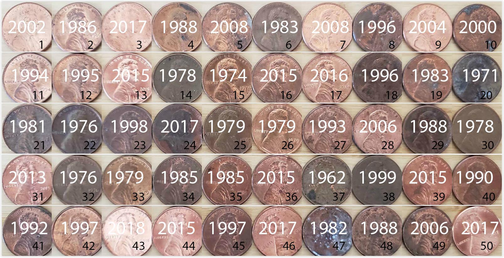

MD Figure 8.2: 50 US pennies labelled (pennies_sample).

#### EDA on the `pennies_sample`

What is the shape, center, and spread (variability) of the sample?

- Create a histogram and QQ plot to assess shape
- Create a boxplot to detect the presence of outliers
- Compute the sample mean and standard deviation
- Also, tabulate the frequency (count) of different years

##### Structure

```r
glimpse(pennies_sample)
```

```
Rows: 50
Columns: 2
$ ID   <int> 1, 2, 3, 4, 5, 6, 7, 8, 9, 10, 11, 12, 13, 14, 15, 16, 17, 18, 19…
$ year <dbl> 2002, 1986, 2017, 1988, 2008, 1983, 2008, 1996, 2004, 2000, 1994,…
```

```r
head(pennies_sample)
```

```
# A tibble: 6 × 2
     ID  year
  <int> <dbl>
1     1  2002
2     2  1986
3     3  2017
4     4  1988
5     5  2008
6     6  1983
```

##### QQ Plot

##### Boxplot

##### Mean and SD

##### Frequency Table

#### Some Questions…

Q1: Did we sample with or without replacement here?

**ANSWER:**

Q2: What is your best guess about the population size $N$?

**ANSWER:**

Q3: Is it reasonable to assume the pennies are independent?

**ANSWER:**

Q4: Do you think this sample is representative of pennies in 2019?

**ANSWER:**

### Replicating the Tactile Resample

The [book](https://moderndive.com/8-confidence-intervals.html) describes a tactile resampling activity using slipsof paper in a hat in which there was a total of 35 resamples. You will replicate this virtually.

#### Bootstrap Resampling Method

- Treat the sample as if it is the population.
- Repeatedly resample from it *with replacement*. (use same $n$)
- Compute the relevant statistic from each resample.
- Analyze the *re-*sampling distribution: shape, mean, standard error (SE).

#### Take 1 Resample of Size 50

```r
my_virtual_resample <- pennies_sample %>%
  rep_sample_n(size = 50, replace = TRUE)
my_virtual_resample
```

```
# A tibble: 50 × 3
# Groups:   replicate [1]
   replicate    ID  year
       <int> <int> <dbl>
 1         1    19  1983
 2         1    39  2015
 3         1     1  2002
 4         1    46  2017
 5         1    45  1997
 6         1    34  1985
 7         1    38  1999
 8         1    11  1994
 9         1    41  1992
10         1    36  2015
# … with 40 more rows
```

#### Take 35 Resamples of Size 50

##### Compute the Resampled Means

##### Histogram of Resampled Means

### Taking More Samples!

#### Take 1000 Resamples of Size 50

#### Distribution of 1000 Resamples

What is the shape, center, and spread (variability) of the resampled means?

- Create a histogram and QQ plot to assess shape
- Create a boxplot to detect the presence of outliers
- Compute the resample mean and standard error

##### Histogram

##### QQ Plot

##### Boxplot

##### Mean and Standard Error

### Computing Interval Estimates

#### Traditional Confidence Interval

#### Bootstrap Percentile Interval

#### Bootstrap SE Interval